# Financial_Analytics - CAPM

Guilherme, Helena, Sérgio e Vinícius

11/19/2020

# Objetivo

O objetivo dessa apresentação é analisar o valor obtido de $\beta$, do modelo CAPM para 4 diferentes ativos usando 3 diferentes métodos para obtenção desse coefientes.

Na análise realizada, foram comparados os $\beta s$ para diferentes ações utilizando os métodos descritos nos slides anteriores. Após o cálculo desses coeficientes foram feitas análises sobre os valores obtidos para cada ação. Essas análises foram:

- **Gráfica:** comparando os valores de $\beta$ para os 3 métodos ao longo do tempo
- **Erro:** comparando os valores de $\beta$ calculados vs. os valores de $\beta$ obtidos
- **Backtest:** comparando os valores de $\beta$ dos 3 métodos para períodos futuros

# Capital Asset Pricing Model - CAPM <sup>1</sup>

CAPM é um modelo que calcula o retorno esperado de um ativo acima de um ativo “livre” de risco de mercado (geralmente um título público). Essa a taxa de retorno adicional é medido pelo coeficiente beta, de uma equação linear:

$\small R_{Mercado} = R_{RiskFree} + \beta(R_{Asset} - R_{RiskFree})$

No presente trabalho, serão realizadas diferentes metodologias para determinação do coeficiente $\beta$.

<sup>1</sup> Definições adaptadas de: https://corporatefinanceinstitute.com/resources/knowledge/finance/what-is-capm-formula/

# Metodologia 1: Regressão Linear

Analisando bem a equação de CAPM, é possível ver uma similaridade com uma equação conhecida. Substitua o $R_{Mercado}$ por um $y$. Agora, substitua o $\small R_{RiskFree}$ por um $b$, o $\beta$ por um $a$ e o $\small (R_{Asset} - R_{RiskFree})$ por um $x$. Após essas substituições, temos a seguinte equação:

$\small R_{Mercado} = R_{RiskFree} + \beta(R_{Asset} - R_{RiskFree}) => y = b + ax$.

Essa equação talvez se apresente mais familiar: equação de primeiro grau (grau 1 e ordem 1) ou equação linear de ordem 1.

Por ser uma equação linear do tipo $\small y = b + ax$, a primeira metodologia que surge é a de uma regressão linear.

Para tal podemos utilizar algumas metodologias para definir o coeficiente $\beta$, dado que os demais dados são dados conhecidos:

- $\small R_{RiskFree}$ = Retorno de um ativo de ‘livre’ de risco
- $\small R_{Mercado}$ = Retorno
- $\small R_{Asset}$ = Retorno do Ativo (ou carteira) a ser investido

A regressão linear é suficiente para poder definir essa $\beta$. Entretanto, fica a pergunta: esse $\beta$ é sempre igual ao longo do tempo? Resposta: **Não**.

Serão então apresentados a seguir outros métodos para definição desse coeficiente.

# Modelo Linear Dinâmico

O modelo linear dinâmico é um modelo iterativo linear. Este modelo repete o modelo linear diversas vezes com diferentes amostras de maneira a calcular o $\beta$ diferente em cada instante de tempo.

Existem 2 técnicas de uso desse modelo:

- **Rolling ou Sliding Window:** amostra móvel em ambas as extremidades, sempre com o mesmo número de elementos em cada amostra
- **Expanding Window:** amostra onde o ponto inicial é fixado e o ponto final é incrementado, sempre com um número acumulativo de dados na amostra

Essas duas técnicas serão melhor explicadas a seguir

# Modelo Linear Dinâmico

### Rolling ou Sliding Window

A técnica de Rolling Window (também conhecida como Sliding Window) tem por princípio, realizar $n$ regressões para uma ‘janela’ móvel de $m$ observações. Esse modelo realiza um processo iterativo, onde em cada iteração, o $\beta$ é calculado com base em uma regressão linear que considera os $m$ dias anteriores.

Neste caso, o primeiro $\beta$ é calculado inicialmente para o dia $\small m+1$, usando os dados dos $m$ dias anteriores.

Na próxima iteração a ‘janela’ de $\small m$ dias é deslocada em 1 dia e um novo $\beta$ é calculado para o dia seguinte ($\small m+2$).

Esse processo é repetido até que a amostra dos últimos $\small m$ dias seja utilizada.

##### Rolling Window Example<sup>2</sup>

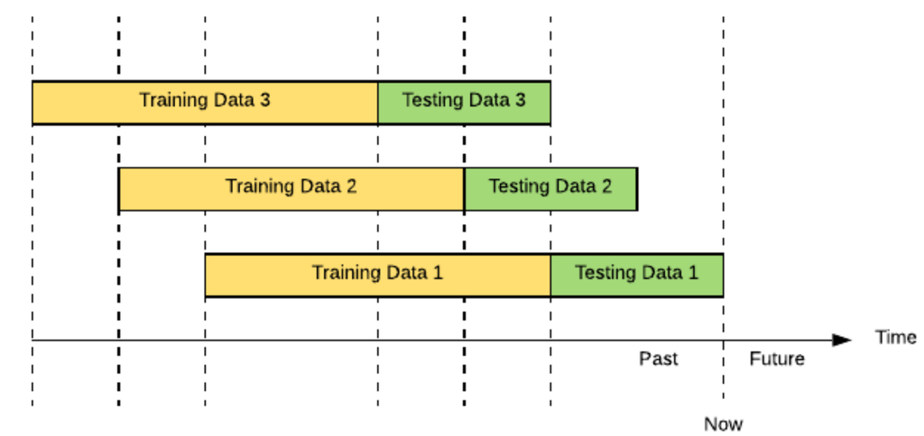

# Modelo Linear Dinâmico

### Expanding Window

A técnica de Expanding Windows é parecida com a técnica de Rolling Window com uma pequena diferença. Essa técnica também é baseada em um modelo linear que é repetido iterativamente com uma nova amostra dos dados, entretanto, nesta técnica, o tamanho da amostra não é fixo. Diferente da técnica anterior, a janela de amostra é aumentada a cada nova iteração, conforme apresentado abaixo:

Na primeira iteração, a amostra da técnica de Expanding Window é identica a primeira amostra da técnica Rolling Window, ou seja, o valor de $\beta$ para o dia $\small m+1$ é calculado sobre uma amostra de $\small m$ dias.

Na seguinte iteração, o $\beta$ é agora calculado sobre um amostra de $\small m+1$ dias, onde o início da amostra permanece inalterado (dia 1 da série) e o fim da amostra ocorre 1 dia após.

Seguindo a mesma lógica, são feitas então as demais iterações, onde a cada nova iteração a amostra é aumentada em 1 dia (inicio no 1<sup>o</sup> dia e término no dia anterior ao dia de interesse).

Um fato relevante é que na última amostra, todos os dados da série são usados e portanto esse último $\beta$ é igual ao $\beta$ do Modelo Linear Estático. Sendo assim, ao plotar um gráfico de $\small dias$ vs. $\beta$ + linha $\beta_{estático}$, ver-se-á um gráfico onde o $\beta$ tende a se aproximar cada vez mais do valor estático ao final da série.

##### Expanding Window Example<sup>2</sup>

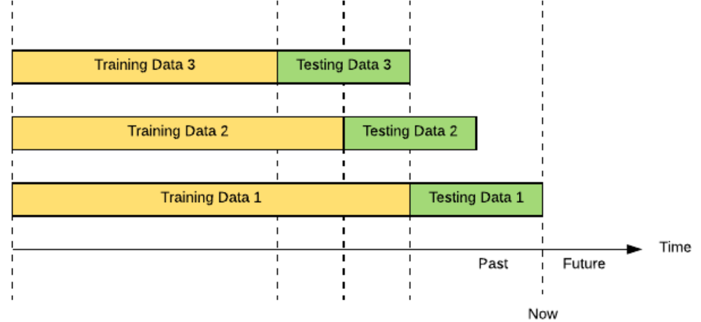

# Betas Variantes no tempo (Time-Varying Betas)

### Tsay - An Intr Analysis of Financial Data With R - 5.3.1

O modelo de Time-Varying Betas do livro Tsay, considera o $\beta$ como um coeficiente variante no tempo. Nesse caso, é feita também uma aproximação em que não é considerada como variável independente o excesso retorno $\small R_{Asset} - R_{RiskFree}$, mas sim o $\small R_{Asset}$. Sendo assim a equação de CAPM é simplificada para $\small R_{Mercado} = R_{RiskFree} + \beta R_{Asset}$.

Esse coeficiente é calculado com base na correlação entre os valores de $\small R_{Asset}$ e $\small R_{RiskFree}$ ao longo do tempo.

Para esse cálculo, é utilizado o princípio estatítico:

$\small Var(x_t + y_t) = Var(x_t) + 2Cov(x_t , y_t) + Var(y_t)$ $\small Var(x_t - y_t) = Var(x_t) - 2Cov(x_t , y_t) + Var(y_t)$

Que permite isolar a covariância e calculá-la com base nas variâncias combinadas dos ativos:

$\small Cov(x_t , y_t) = {Var(x_t + y_t) − Var(x_t − y_t) \over 4}$

Dado que a volatilidade $\sigma_{x,t}$ é dada pela $\sqrt{var(x_t)}$ em um dado período, podemos então lançar mão de modelos GARCH para cálculo das variâncias ao longo do tempo e assim, calcular a Covariância. Aqui, será assumido um modelo GARCH(1,1).

De posse do valores de Covariância, temos então que calcular a Correlação entre $x_t$ e $y_t$.

$\small Corr(x_t,y_t) = {Cov(x,y) \over Var(x)Var(y)} => Corr(x_t,y_t) = {Var(x_t + y_t) − Var(x_t − y_t) \over 4 \sqrt{Var(x)}\sqrt{Var(y)}}$

# Importando as cotações históricas

# Ações - Petrobrás

```
##      Index            PETR4.SA.Adjusted
##  Min.   :2007-01-02   Min.   : 3.896
##  1st Qu.:2010-06-17   1st Qu.:14.624
##  Median :2014-01-15   Median :18.532
##  Mean   :2013-12-24   Mean   :19.307
##  3rd Qu.:2017-06-21   3rd Qu.:24.086
##  Max.   :2020-11-19   Max.   :42.204
```

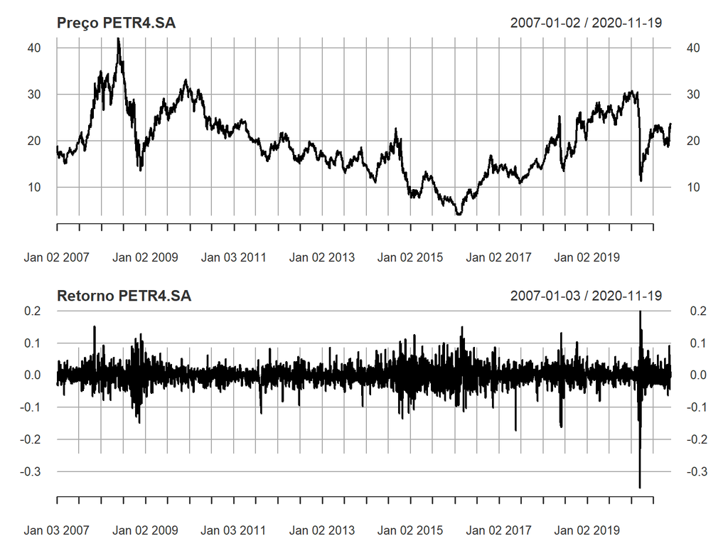

# Ações - Vale do Rio Doce

```
##      Index            VALE3.SA.Adjusted
##  Min.   :2007-01-02   Min.   : 7.357
##  1st Qu.:2010-06-23   1st Qu.:23.146
##  Median :2013-12-20   Median :28.093
##  Mean   :2013-12-16   Mean   :30.378
##  3rd Qu.:2017-06-12   3rd Qu.:37.163
##  Max.   :2020-11-19   Max.   :67.720
```

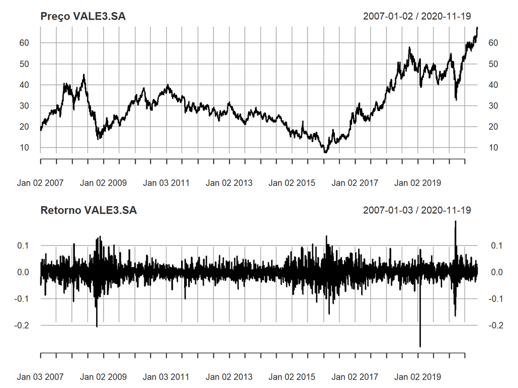

# Ações - Via Varejo

```
##      Index            VVAR3.SA.Adjusted
##  Min.   :2007-01-02   Min.   : 1.025
##  1st Qu.:2010-05-12   1st Qu.: 3.196
##  Median :2014-03-28   Median : 4.901
##  Mean   :2014-01-21   Mean   : 5.402
##  3rd Qu.:2017-07-26   3rd Qu.: 6.959
##  Max.   :2020-11-19   Max.   :21.290
```

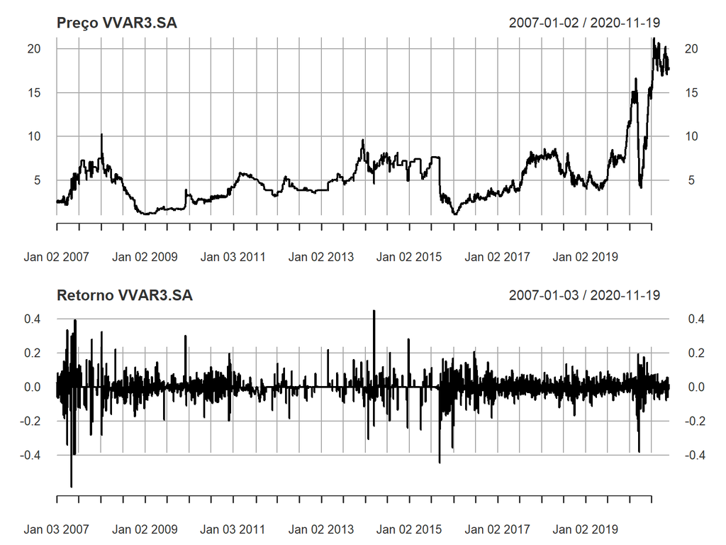

# Ações - CEMIG

```
##      Index            CMIG4.SA.Adjusted
##  Min.   :2007-01-02   Min.   : 2.980
##  1st Qu.:2010-06-25   1st Qu.: 6.806
##  Median :2013-12-12   Median : 7.790
##  Mean   :2013-12-13   Mean   : 8.319
##  3rd Qu.:2017-06-07   3rd Qu.: 9.252
##  Max.   :2020-11-19   Max.   :14.894
```

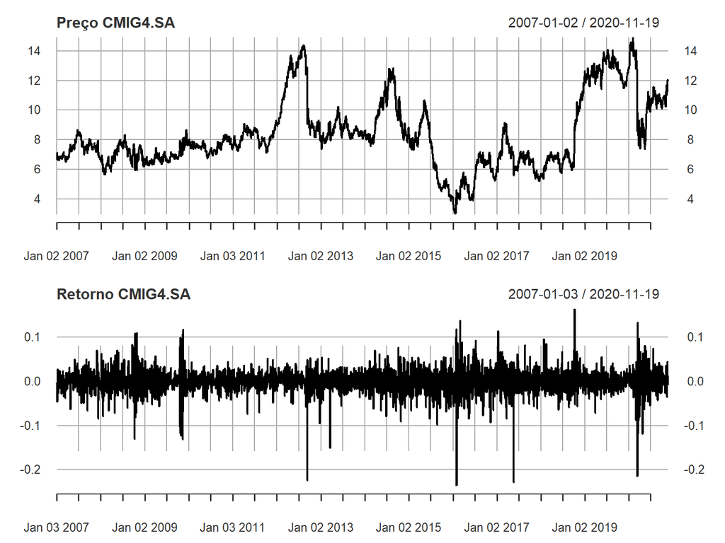

# Ações - Ibovespa

```
##      Index            BVSP.Adjusted
##  Min.   :2007-01-02   Min.   : 29435
##  1st Qu.:2010-06-24   1st Qu.: 52745
##  Median :2013-12-09   Median : 60361
##  Mean   :2013-12-11   Mean   : 64440
##  3rd Qu.:2017-05-30   3rd Qu.: 70221
##  Max.   :2020-11-19   Max.   :119528
```

```
## [1] 3429
```

```
## [1] 3399
```

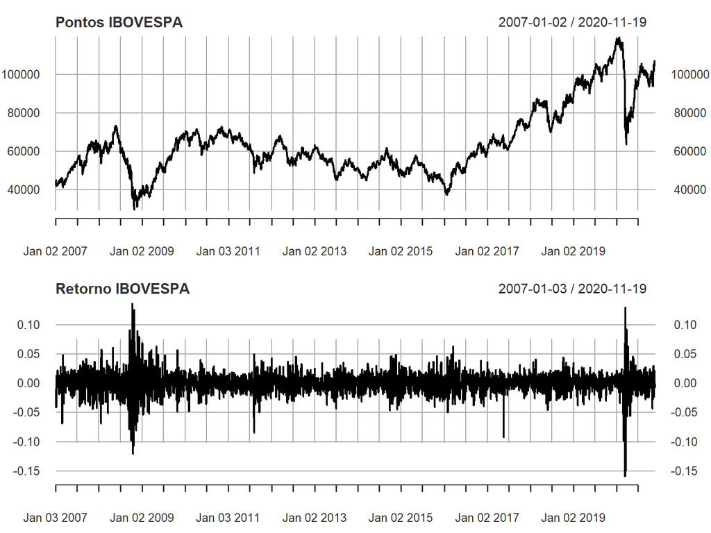

# Ações - Taxa Básica Juros SELIC

```
##      Index                  rf
##  Min.   :2007-01-02   Min.   :0.00007469
##  1st Qu.:2010-06-24   1st Qu.:0.00028296
##  Median :2013-12-09   Median :0.00040203
##  Mean   :2013-12-10   Mean   :0.00036912
##  3rd Qu.:2017-05-31   3rd Qu.:0.00045513
##  Max.   :2020-11-20   Max.   :0.00052531
```

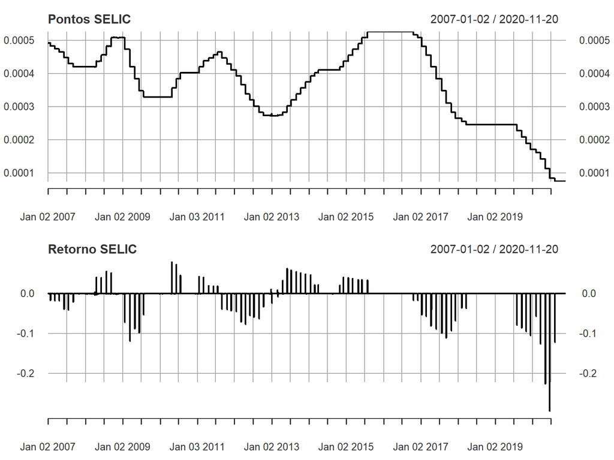

# Calculando Beta Linear Estático - Petrobrás

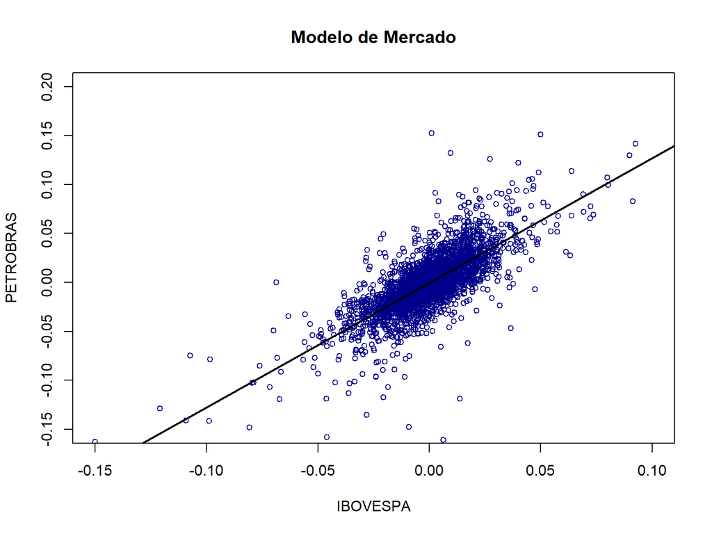

O valor do $\beta_{est_{petr}}$ é 1.2731693.

# Calculando Beta Linear Estático - Vale

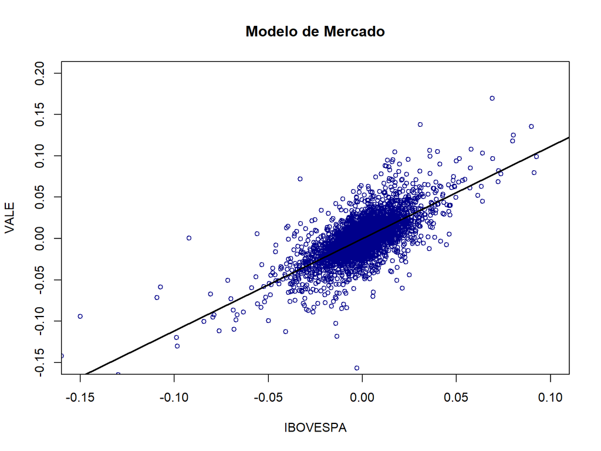

O valor do $\beta_{est_{vale}}$ é 1.1141599.

# Calculando Beta Linear Estático - Via Varejo

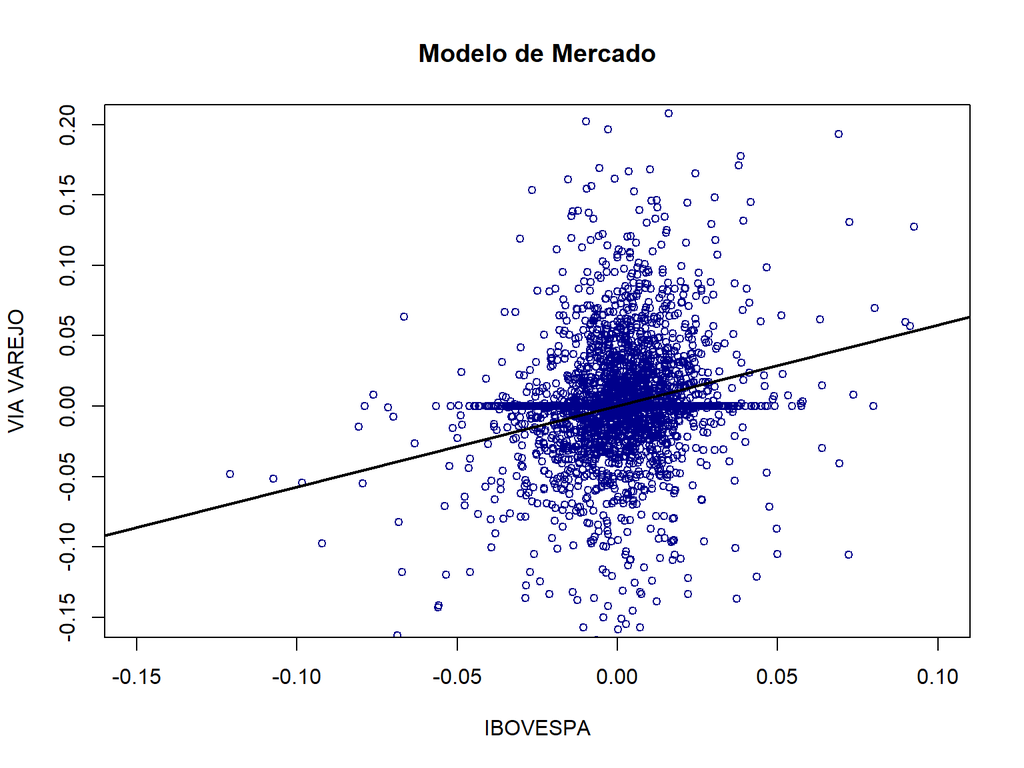

O valor do $\beta_{est_{vvar}}$ é 0.5752312.

# Calculando Beta Linear Estático - Cemig

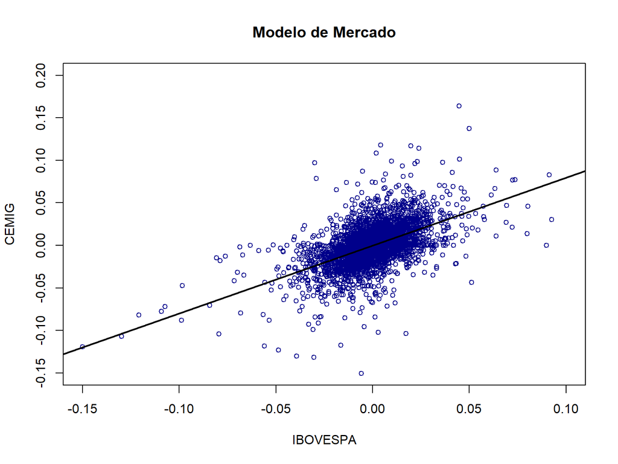

O valor do $\beta_{est_{cmig}}$ é 0.7987752.

# Betas Lineares Estáticos - Resumo

|  | Acao | betas |
| --- | --- | --- |
| 1 | Petrobrás | 1.273 |
| 2 | Vale | 1.114 |
| 3 | Via Varejo | 0.575 |
| 4 | Cemig | 0.799 |

# Calculando Beta Linear Dinâmico (Roilling Window)